# EDA

Austin Okafor

2022-06-28

# For his section of the project, we will utilize some R packages for Automated Exploratory Data Analysis. This is especially useful because of the size of the data we are working with, the complexity of the variables, and the number of columns in the dataframe.

Let us install tidyverse, DataExplorer, and SmartEDA. These will be used for our EDA work.

```r
# install.packages("tidyverse")
library(dplyr)
library(readr)
# install.packages("DataExplorer")
library(DataExplorer)
# install.packages("SmartEDA")
library(SmartEDA)
```

Now, leveraging our previous knowledge of the data from the Descriptive Statistics analysis conducted in our last work, we will load the dataset and assign column types automatically. We will however not change any data value.

```r
# I chose not to alter the data in any way because most of the column types are factors.I felt that changing the original values may distort the true understanding of how the data is distributed, because certain levels will be lost.

# Also, due to the number of columns, it was very tedious trying to obtain the column types and ensuring no error was made during assignment. I had to redo this steps several times to ensure accuracy.

# read csv file
dataframe <-
  read_delim(
    file = "developmental_services_survey_dataset_0.csv",
    col_types = "iffffccfccfffffcfffffffffffffffffffffffffffffcccccnncccccccfcccfccccffcccccf",
    delim=",")
# Reading the first few lines of the dataset
head(dataframe)
```

```
## # A tibble: 6 x 76
##     UID SERVICES PR_Q3D PR_AGE1 PR_QF1A PR_QF1B PR_QF1C PR_QG1A PR_QG1B PR_QG1C
##   <int> <fct>    <fct>  <fct>   <fct>   <chr>   <chr>   <fct>   <chr>   <chr>
## 1     1 3        1      1       1       1       -99     1       1       -99
## 2     2 3        1      2       1       1       -99     1       1       -99
## 3     3 3        2      1       1       1       -99     1       1       -99
## 4     4 3        1      2       1       1       -99     1       1       -99
## 5     5 3        2      2       1       1       -99     1       1       -99
## 6     6 3        1      2       1       1       -99     1       1       -99
## # ... with 66 more variables: PR_QH1A <fct>, PR_QH1B <fct>, PR_QI1 <fct>,
## #   PR_QJ1 <fct>, PR_QK1 <fct>, PR_QL1 <chr>, PR_QL1A_1 <fct>, PR_QL1A_2 <fct>,
## #   PR_QL1A_3 <fct>, PR_QL1A_4 <fct>, PR_QM1A <fct>, PR_QM1B <fct>,
## #   PR_QM1C <fct>, PR_QN1_A <fct>, PR_QN1_B <fct>, PR_QN1_C <fct>,
## #   PR_QN1_D <fct>, PR_QN1_E <fct>, PR_QN1_F <fct>, PR_QN1_G <fct>,
## #   PR_QN1_H <fct>, PR_QO1_A_COMBINE <fct>, PR_QO1_B_COMBINE <fct>,
## #   PR_QO1_C_COMBINE <fct>, PR_QO1_D_COMBINE <fct>, PR_QO1_E_COMBINE <fct>, ...
```

We will now remove the UID column as this is not useful for any analysis.

```r
# remove the id
dataframe <- dataframe[ ,-1]


# view data structure and confirm column types and UID column removal
str(dataframe)
```

```
## tibble [33,615 x 75] (S3: tbl_df/tbl/data.frame)
##  $ SERVICES        : Factor w/ 3 levels "3","1","2": 1 1 1 1 1 1 1 1 1 1 ...
##  $ PR_Q3D          : Factor w/ 3 levels "1","2","-99": 1 1 2 1 2 1 2 2 1 2 ...
##  $ PR_AGE1         : Factor w/ 7 levels "1","2","3","4",..: 1 2 1 2 2 2 2 2 1 1 ...
##  $ PR_QF1A         : Factor w/ 5 levels "1","2","-99",..: 1 1 1 1 1 1 2 1 1 1 ...
##  $ PR_QF1B         : chr [1:33615] "1" "1" "1" "1" ...
##  $ PR_QF1C         : chr [1:33615] "-99" "-99" "-99" "-99" ...
##  $ PR_QG1A         : Factor w/ 5 levels "1","-99","2",..: 1 1 1 1 1 1 1 1 1 1 ...
##  $ PR_QG1B         : chr [1:33615] "1" "1" "1" "1" ...
##  $ PR_QG1C         : chr [1:33615] "-99" "-99" "-99" "-99" ...
##  $ PR_QH1A         : Factor w/ 7 levels "1","5","3","-99",..: 1 1 1 1 1 1 2 1 1 1 ...
##  $ PR_QH1B         : Factor w/ 4 levels "-99","1","2",..: 1 1 1 1 1 1 2 1 1 1 ...
##  $ PR_QI1          : Factor w/ 7 levels "1","5","-99",..: 1 1 1 1 1 1 1 1 1 1 ...
##  $ PR_QJ1          : Factor w/ 7 levels "1","2","-99",..: 1 1 1 1 2 1 1 1 1 1 ...
##  $ PR_QK1          : Factor w/ 7 levels "1","5","2","-99",..: 1 1 1 1 1 1 2 1 1 1 ...
```

[output cut: 61 more lines]

Now let us learn more about the data distrubution by running summary

```r
summary(dataframe)
```

```
##  SERVICES  PR_Q3D      PR_AGE1    PR_QF1A       PR_QF1B
##  3:18369   1  :19156   1  :6141   1  :25446   Length:33615
##  1: 7673   2  :14385   2  :7565   2  : 5411   Class :character
##  2: 7573   -99:   74   3  :6169   -99: 1411   Mode  :character
##                        4  :7267   3  :  896
##                        5  :4485   -88:  451
##                        6  :1887
##                        -99: 101
##    PR_QF1C          PR_QG1A       PR_QG1B            PR_QG1C
##  Length:33615       1  :30141   Length:33615       Length:33615
##  Class :character   -99: 1427   Class :character   Class :character
##  Mode  :character   2  : 1007   Mode  :character   Mode  :character
##                     3  :  576
##                     -88:  464
##
##
##  PR_QH1A     PR_QH1B     PR_QI1      PR_QJ1      PR_QK1         PR_QL1
##  1  :23841   -99:26240   1  :28984   1  :29360   1  :26052   Length:33615
##  5  : 4704   1  : 4144   5  : 1305   2  :  383   5  : 2544   Class :character
##  3  : 1148   2  : 3197   -99: 1439   -99: 1494   2  :  895   Mode  :character
##  -99: 1426   -88:   34   -88: 1175   5  :  664   -99: 1476
##  4  :  955               3  :  224   4  :  227   3  : 1017
##  2  :  677               2  :  280   -88: 1097   -88:  932
##  -88:  864               4  :  208   3  :  390   4  :  699
##  PR_QL1A_1   PR_QL1A_2   PR_QL1A_3   PR_QL1A_4   PR_QM1A     PR_QM1B
##  0  :10050   1  : 9051   0  :10390   0  : 8818   -88: 1871   2  :23240
##  -99:22776   -99:22776   -99:22776   -99:22776   1  :29621   -88: 2394
##  1  :  789   0  : 1788   1  :  449   1  : 2021   2  :  637   1  : 6288
##                                                  -99: 1486   -99: 1693
##
##
##
##  PR_QM1C     PR_QN1_A    PR_QN1_B    PR_QN1_C    PR_QN1_D    PR_QN1_E
##  1  : 1746   1  : 5384   -88: 3216   -88: 3011   1  : 6325   3  :28342
##  -88: 8545   3  :23596   3  :25165   3  :26722   3  :20329   -88: 2272
##  2  :21493   -88: 2105   2  :  614   -99: 1838   -88: 3201   -99: 1879
##  -99: 1831   -99: 1736   1  : 2858   1  : 1789   -99: 1756   2  :  625
##              2  :  794   -99: 1762   2  :  255   2  : 2004   1  :  497
##
##
```

[output cut: 81 more lines]

```
##  Length:33615       Length:33615       Length:33615       Length:33615
##  Class :character   Class :character   Class :character   Class :character
##  Mode  :character   Mode  :character   Mode  :character   Mode  :character
##
##
##
##
##  C_QS3
##  -99:24560
##  2  : 4224
##  1  : 3248
##  3  :  808
##  4  :  775
##
##
```

```r
# We can observe that quite a umber of columns have missing data represented by -88 and -99. This information is useful in performing further analysis as it would better help understand outliers and data distributions in our charts.
```

Now let us move on to more advanced EDA tools. We will now create an EDA report using DataExplorer.

```r
# Exploratory Data Analysis using DataExplorer

dataframe %>%
    create_report(
        report_title = "Developmental Services Survey Dataset",
        y = "SERVICES", output_dir = getwd()
    )
```

```
##
##
## processing file: report.rmd
```

[output not shown]

[output not shown]

[output not shown]

[output not shown]

[output not shown]

[output not shown]

[output not shown]

[output not shown]

[output not shown]

[output not shown]

[output not shown]

[output not shown]

```
## output file: C:/Users/austi/Downloads/CIND820/Workspace/report.knit.md
```

[output not shown]

```
##
## Output created: report.html
```

```r
# # The HTML otput displays:
# Basic Statistics
# Raw Counts
# Percentages
# Data Structure
# Missing Data Profile
# Univariate Distribution
# Histogram
# Bar Chart (with frequency)
# Bar Chart (by SERVICES)
# QQ Plot
# QQ Plot (by SERVICES)
# Correlation Analysis
# Principal Component Analysis
# Bivariate Distribution
# Boxplot (by SERVICES)
# Scatterplot (by SERVICES)

# It also shows there are
# 33,615 rows, 75 Columns,  73 Discrete columns, and 2 Continuous columns.
#
# The correlation analysis also shows that there are some correlation between variables but due to the number of variables, this is difficult to read.
#
# The principal componenet analysis sections displays feature importance and this is useful for feature selection when creating out samples.
```

Some additional plots are created in the following chunks to further illustrate the description provided abov.

```r
# view data structure using DataExplorer

plot_str(dataframe)
```

[output not shown]

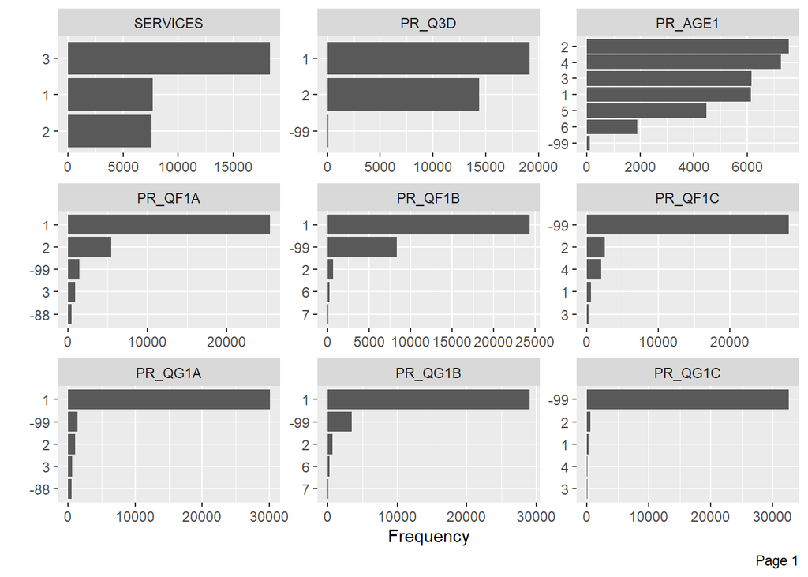

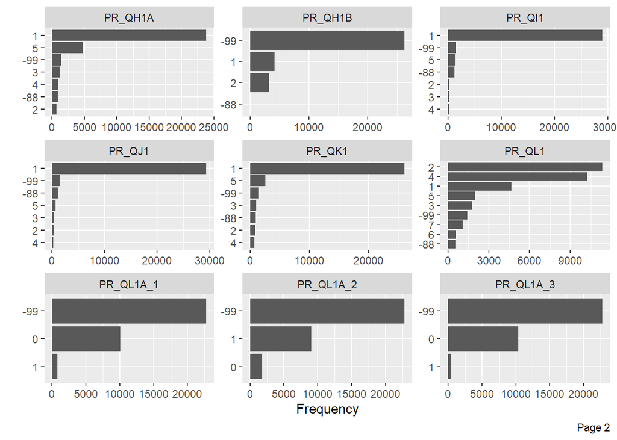

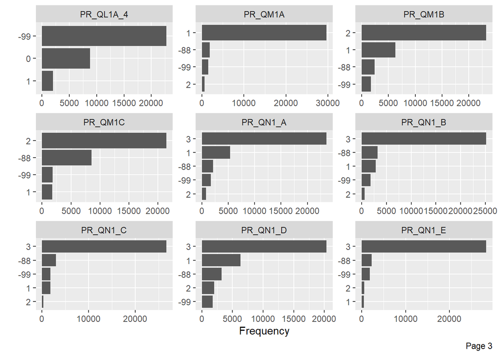

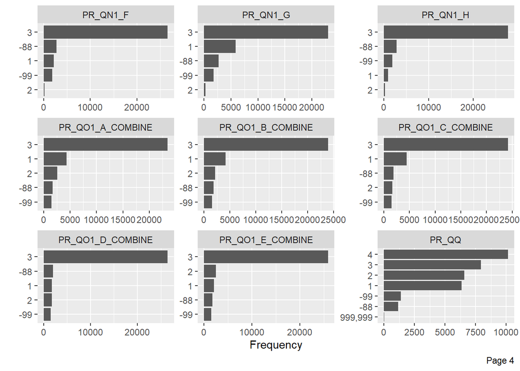

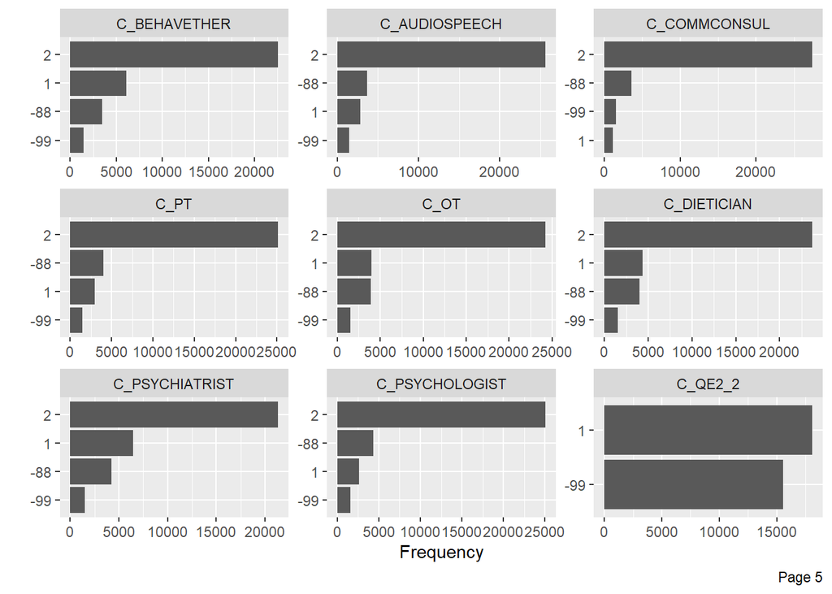

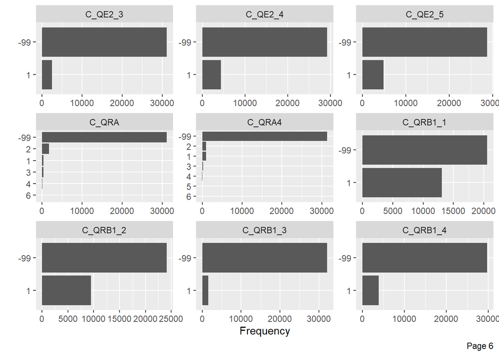

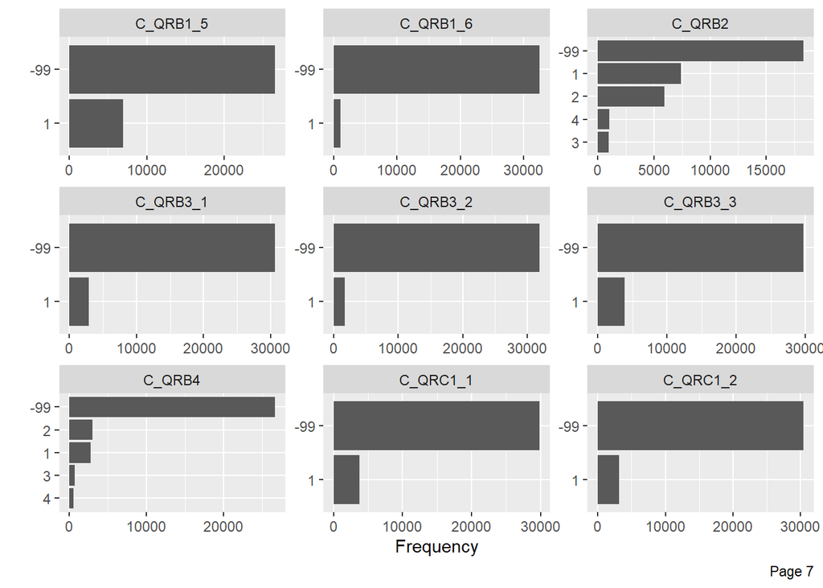

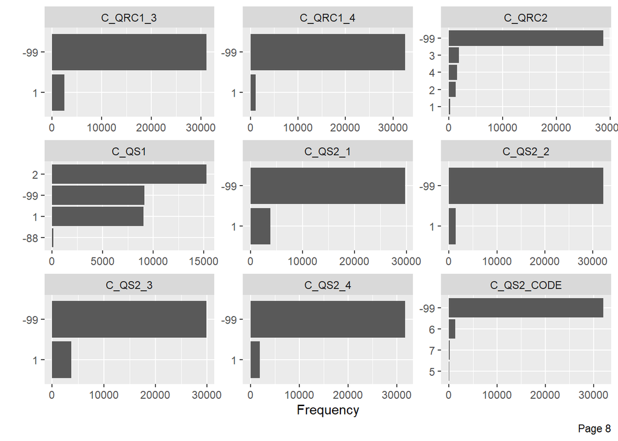

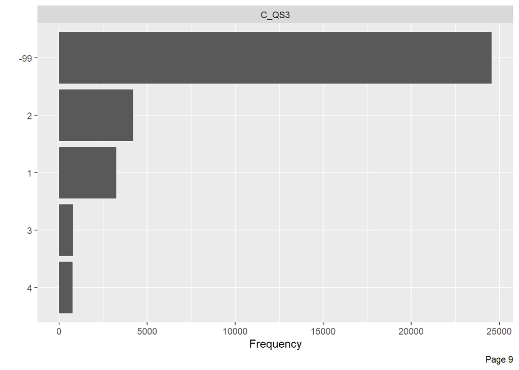

```r
# view bar charts using DataExplorer

plot_bar(dataframe)
```

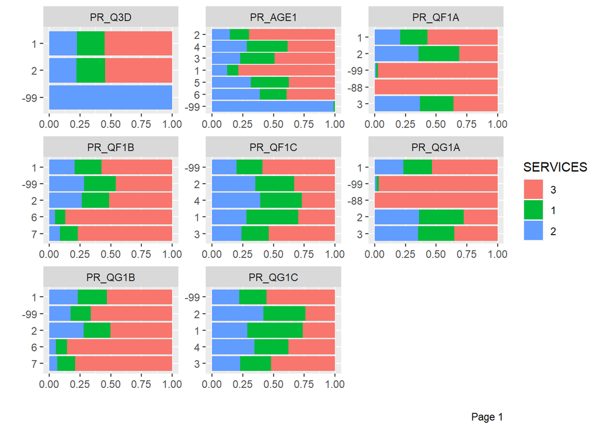

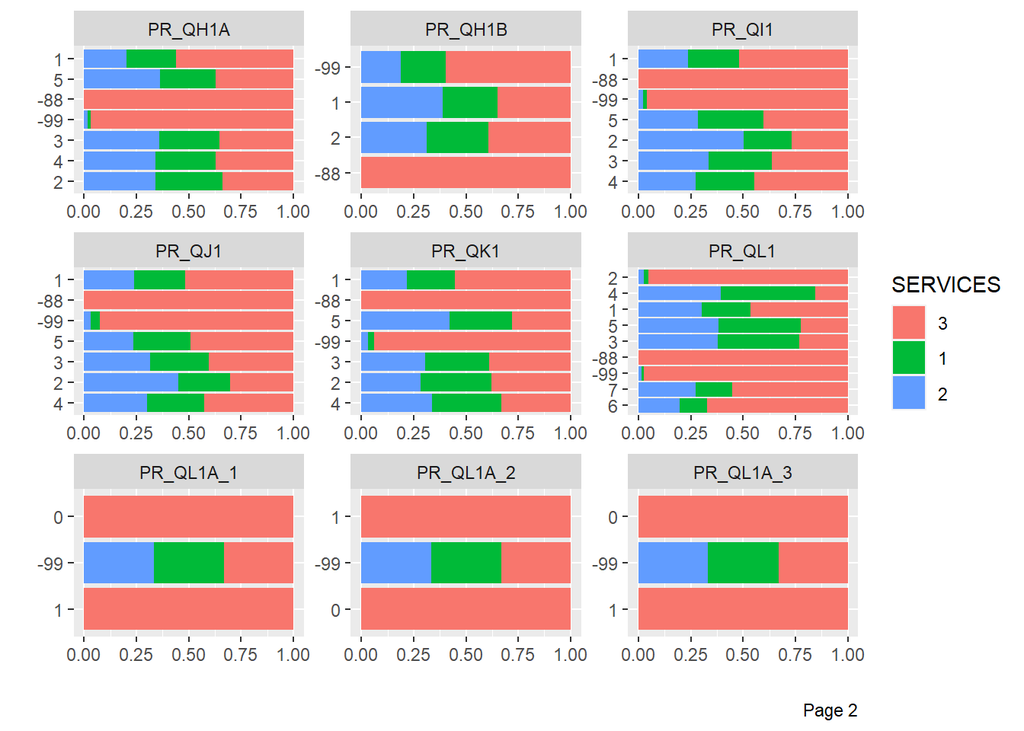

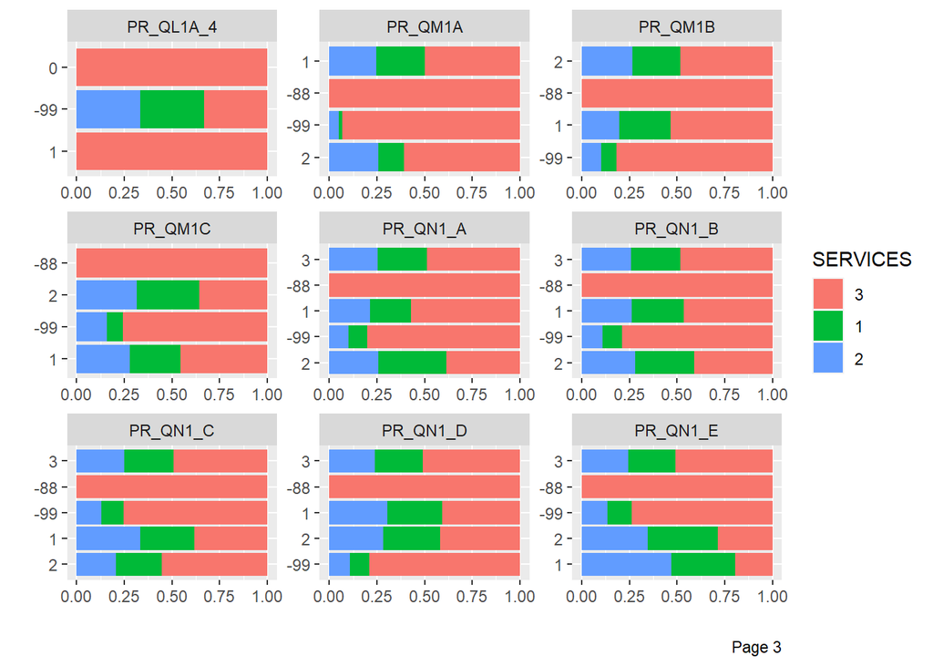

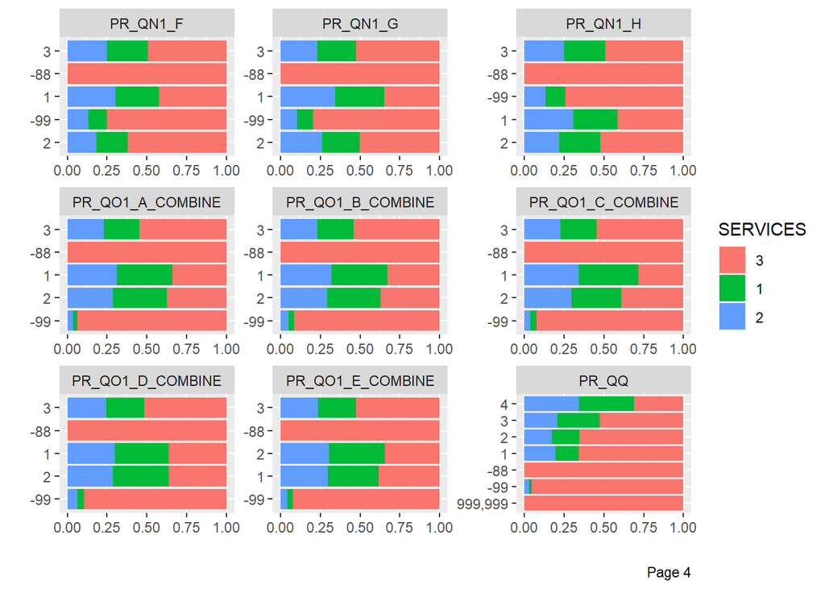

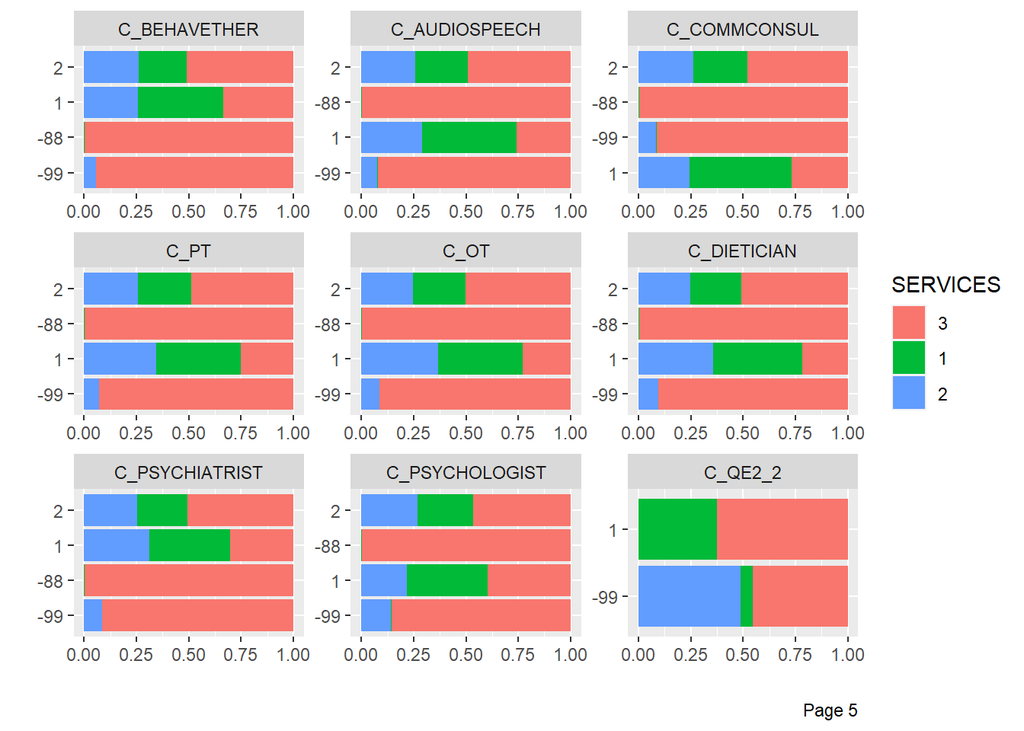

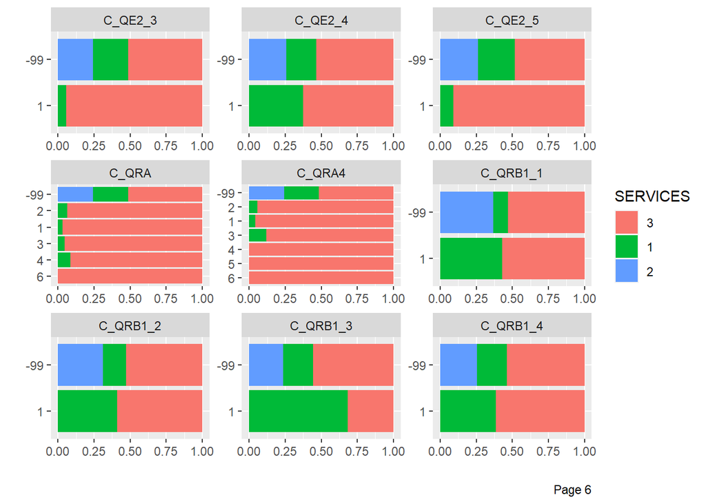

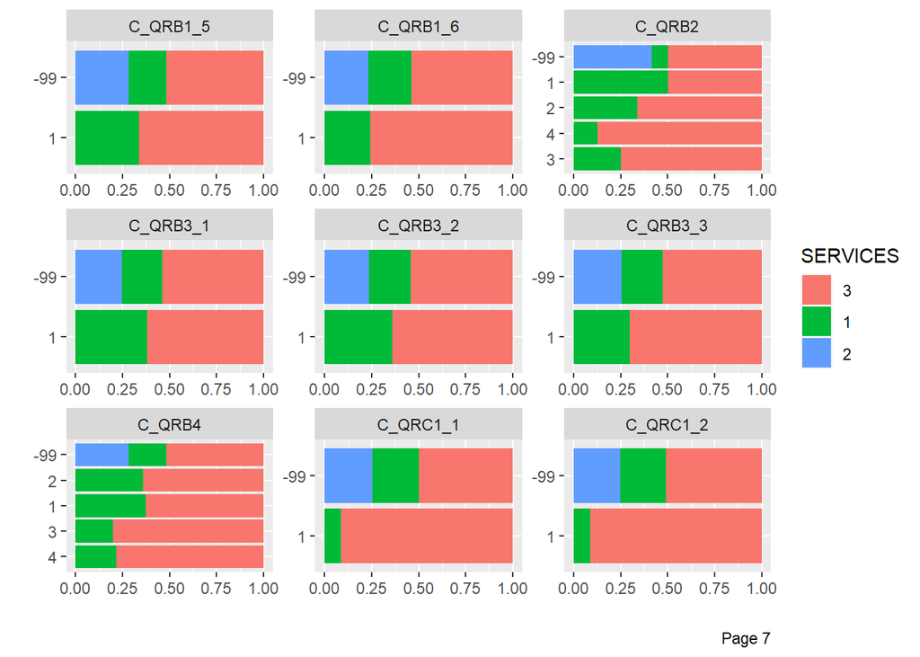

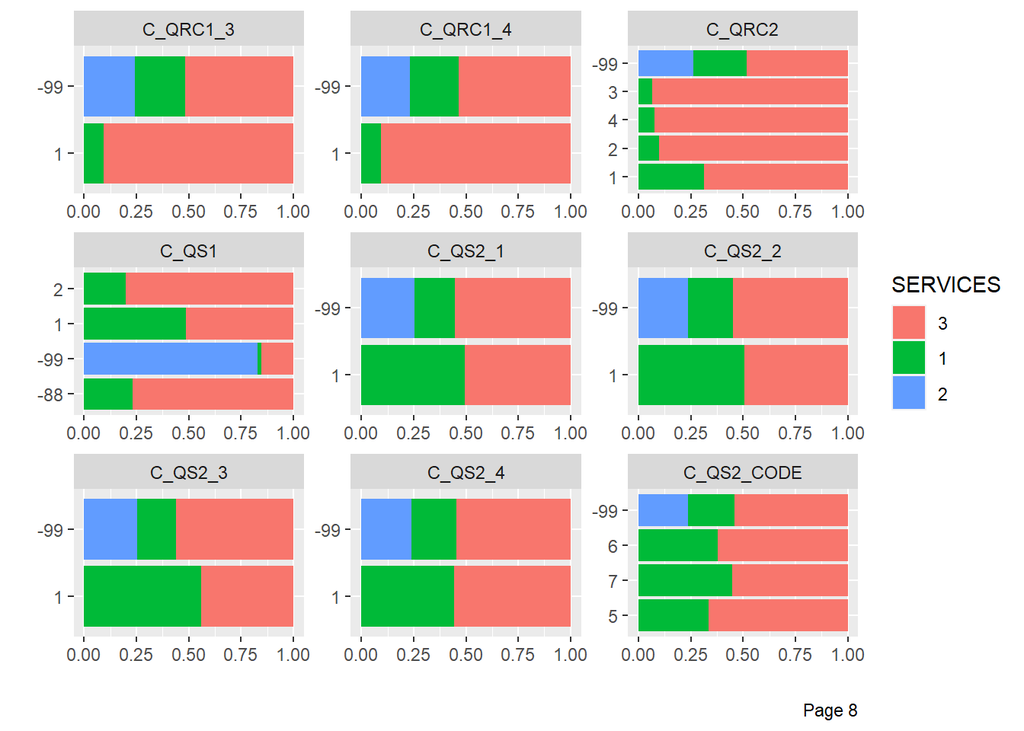

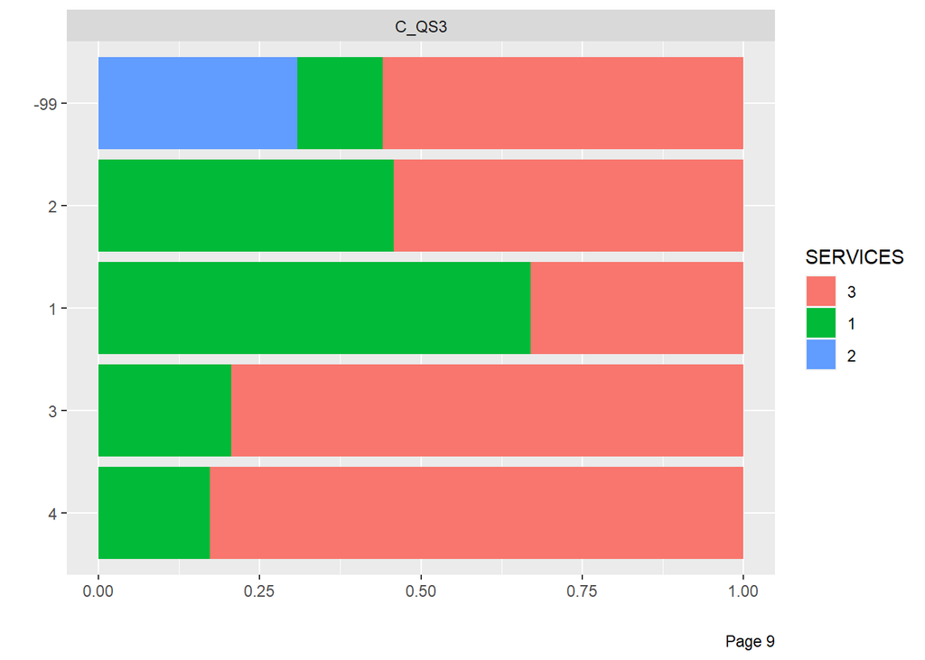

```r
# view bar charts with Services using DataExplorer

plot_bar(dataframe, by="SERVICES")
```

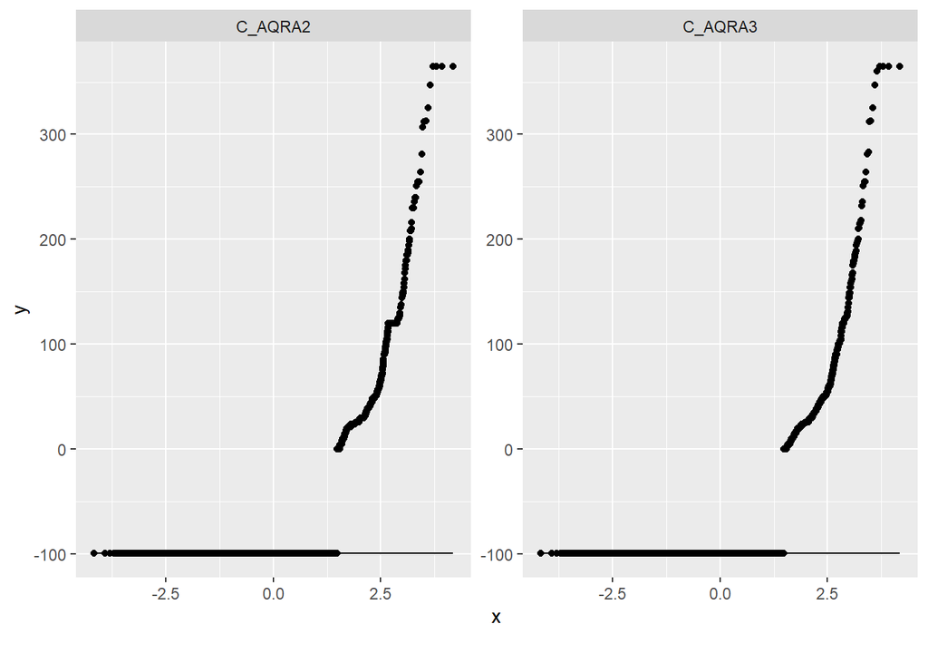

```r
plot_qq(dataframe)
```

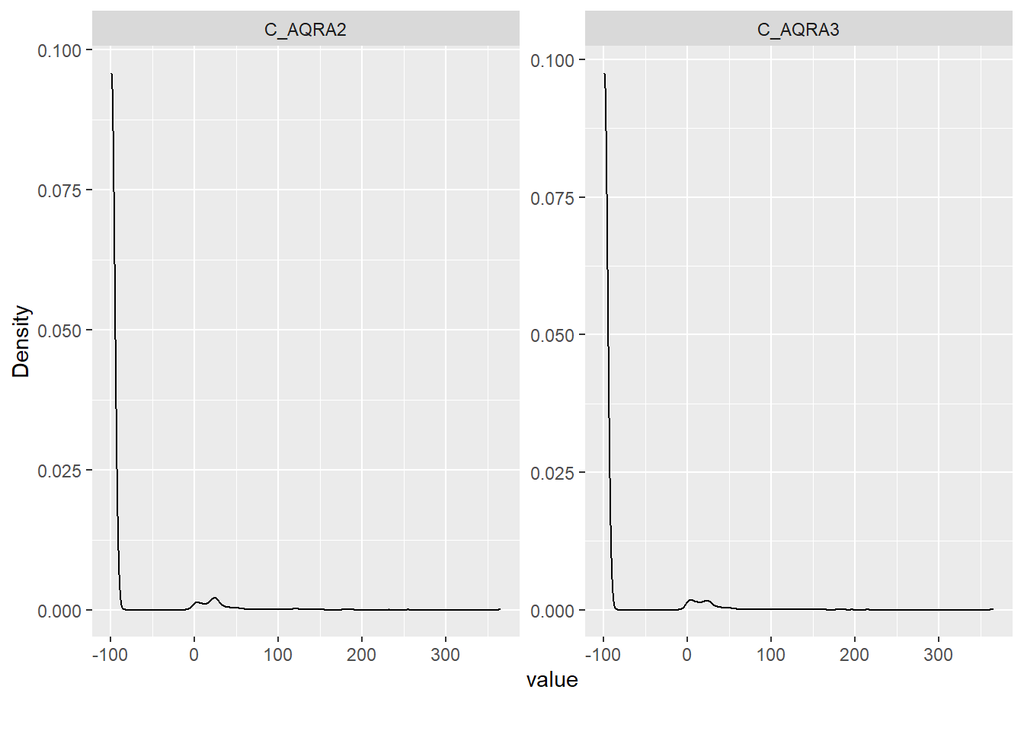

```r
plot_density(dataframe)
```

[figure not shown]

```r
plot_correlation(dataframe)
```

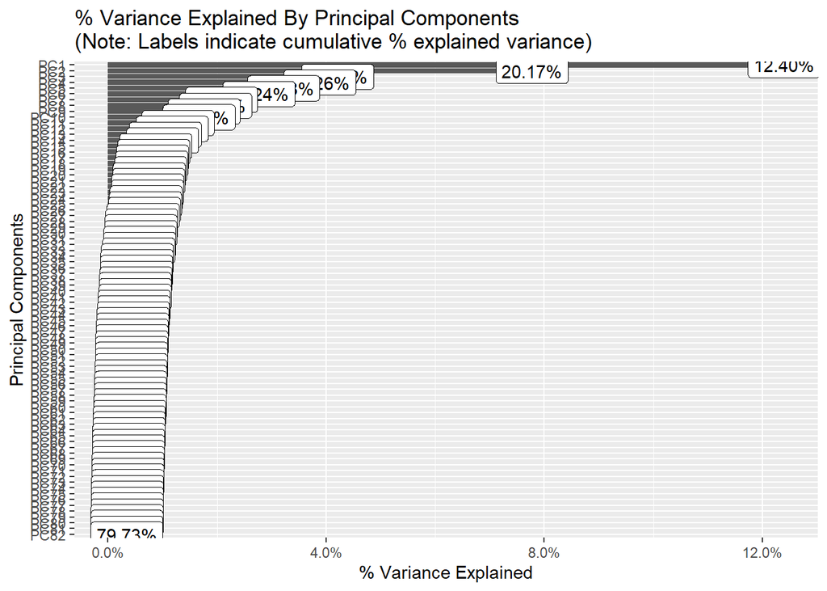

[figure not shown]

[figure not shown]

[figure not shown]

[figure not shown]

[figure not shown]

[figure not shown]

[figure not shown]

[figure not shown]

[figure not shown]

[figure not shown]

```r
plot_prcomp(dataframe)
```

Now let us run a similiar EDA process but this time, using SmartEDA

```r
# This shows the distribution of our dependent variable, services

library(SmartEDA)


#ExpReport(
#  dataframe,
#  Target="SERVICES",
#  label= "Developmental Services Survey Dataset",
#  op_file="SmartEDA.html")
```

[output not shown]

We now view an overview of the dataset using SmartEDA

```r
# Overview of the dataset

ExpData(data=dataframe, type=1)
```

```
##                                           Descriptions     Value
## 1                                   Sample size (nrow)     33615
## 2                              No. of variables (ncol)        75
## 3                    No. of numeric/interger variables         2
## 4                              No. of factor variables        44
## 5                                No. of text variables        29
## 6                             No. of logical variables         0
## 7                          No. of identifier variables         0
## 8                                No. of date variables         0
## 9             No. of zero variance variables (uniform)         0
## 10               %. of variables having complete cases 100% (75)
## 11   %. of variables having >0% and <50% missing cases    0% (0)
## 12 %. of variables having >=50% and <90% missing cases    0% (0)
## 13          %. of variables having >=90% missing cases    0% (0)
```

Then the data structure

```r
# Description of the data structure

ExpData(data=dataframe, type=2)
```

```
##    Index    Variable_Name Variable_Type Sample_n Missing_Count Per_of_Missing
## 1      1         SERVICES        factor    33615             0              0
## 2      2           PR_Q3D        factor    33615             0              0
## 3      3          PR_AGE1        factor    33615             0              0
## 4      4          PR_QF1A        factor    33615             0              0
## 5      5          PR_QF1B     character    33615             0              0
## 6      6          PR_QF1C     character    33615             0              0
## 7      7          PR_QG1A        factor    33615             0              0
## 8      8          PR_QG1B     character    33615             0              0
## 9      9          PR_QG1C     character    33615             0              0
## 10    10          PR_QH1A        factor    33615             0              0
## 11    11          PR_QH1B        factor    33615             0              0
## 12    12           PR_QI1        factor    33615             0              0
## 13    13           PR_QJ1        factor    33615             0              0
## 14    14           PR_QK1        factor    33615             0              0
```

[output cut: 137 more lines]

Now to view the variable importance based on information value. This is particularly importnt for feature selection.

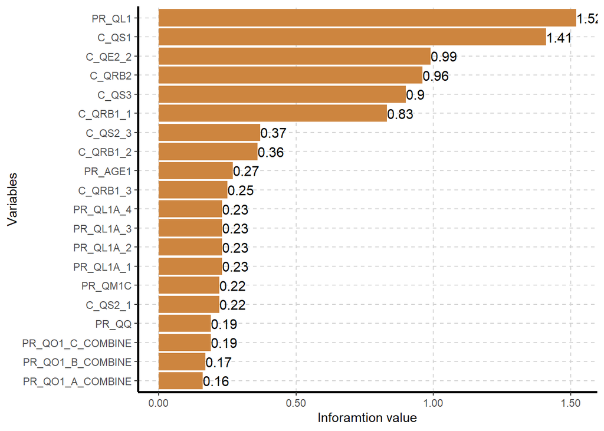

```r
# variable importance based on information value

try <- ExpCatStat(dataframe, Target="SERVICES", Pclass="1", plot=TRUE)
```

# Decision Tree Classification Algorithm

Referencing the outputs of SmartEDA and DataExplorer for feature selection, I will now create a subset of the data using only the columns of high and medium importance. This will then be used for the modeling stage of our analysis in this project.

Creating Subset dataframe using columns with High and Median importance features, and adding labels for variables in services.

```r
# Create a subset of the data and substitute labels for services

subset_Data <- dataframe  %>%
select (c("SERVICES","PR_QL1","C_QE2_2","C_QRB1_1","C_QRB1_2","C_QS2_3","C_QRB2","C_QS1","C_QS3","C_QRB1_3","C_QS2_1","PR_AGE1","PR_QL1A_1","PR_QL1A_2","PR_QL1A_3","PR_QL1A_4","PR_QM1C","PR_QO1_C_COMBINE","PR_QQ")) %>%
  mutate(SERVICES = factor(SERVICES, levels = c(1, 2, 3), labels = c('Residential', 'Non-residential', 'Both')))


head(subset_Data)
```

```
## # A tibble: 6 x 19
##   SERVICES PR_QL1 C_QE2_2 C_QRB1_1 C_QRB1_2 C_QS2_3 C_QRB2 C_QS1 C_QS3 C_QRB1_3
##   <fct>    <chr>  <chr>   <chr>    <chr>    <chr>   <fct>  <fct> <fct> <chr>
## 1 Both     2      -99     -99      -99      -99     -99    2     -99   -99
## 2 Both     3      1       1        -99      -99     2      1     2     -99
## 3 Both     6      -99     -99      -99      -99     -99    2     -99   -99
## 4 Both     2      1       1        1        -99     1      1     2     -99
## 5 Both     2      1       1        1        -99     2      2     -99   -99
## 6 Both     2      1       -99      -99      -99     -99    2     -99   -99
## # ... with 9 more variables: C_QS2_1 <chr>, PR_AGE1 <fct>, PR_QL1A_1 <fct>,
## #   PR_QL1A_2 <fct>, PR_QL1A_3 <fct>, PR_QL1A_4 <fct>, PR_QM1C <fct>,
## #   PR_QO1_C_COMBINE <fct>, PR_QQ <fct>
```

```r
str(subset_Data)
```

```
## tibble [33,615 x 19] (S3: tbl_df/tbl/data.frame)
##  $ SERVICES        : Factor w/ 3 levels "Residential",..: 3 3 3 3 3 3 3 3 3 3 ...
##  $ PR_QL1          : chr [1:33615] "2" "3" "6" "2" ...
##  $ C_QE2_2         : chr [1:33615] "-99" "1" "-99" "1" ...
##  $ C_QRB1_1        : chr [1:33615] "-99" "1" "-99" "1" ...
##  $ C_QRB1_2        : chr [1:33615] "-99" "-99" "-99" "1" ...
##  $ C_QS2_3         : chr [1:33615] "-99" "-99" "-99" "-99" ...
##  $ C_QRB2          : Factor w/ 5 levels "-99","2","1",..: 1 2 1 3 2 1 3 4 1 1 ...
##  $ C_QS1           : Factor w/ 4 levels "2","1","-88",..: 1 2 1 2 1 1 1 1 3 1 ...
##  $ C_QS3           : Factor w/ 5 levels "-99","2","1",..: 1 2 1 2 1 1 1 1 1 1 ...
##  $ C_QRB1_3        : chr [1:33615] "-99" "-99" "-99" "-99" ...
##  $ C_QS2_1         : chr [1:33615] "-99" "-99" "-99" "1" ...
##  $ PR_AGE1         : Factor w/ 7 levels "1","2","3","4",..: 1 2 1 2 2 2 2 2 1 1 ...
##  $ PR_QL1A_1       : Factor w/ 3 levels "0","-99","1": 1 2 2 1 1 1 2 2 2 1 ...
##  $ PR_QL1A_2       : Factor w/ 3 levels "1","-99","0": 1 2 2 1 1 1 2 2 2 1 ...
##  $ PR_QL1A_3       : Factor w/ 3 levels "0","-99","1": 1 2 2 1 1 1 2 2 2 1 ...
##  $ PR_QL1A_4       : Factor w/ 3 levels "0","-99","1": 1 2 2 1 1 1 2 2 2 1 ...
##  $ PR_QM1C         : Factor w/ 4 levels "1","-88","2",..: 1 2 3 3 1 2 2 3 2 3 ...
##  $ PR_QO1_C_COMBINE: Factor w/ 5 levels "3","2","-88",..: 1 1 1 1 1 1 1 2 3 1 ...
##  $ PR_QQ           : Factor w/ 7 levels "-88","2","3",..: 1 2 2 2 3 3 4 5 2 3 ...
```

Prepare data for modeling by splitting the dataset into training and test sets.

```r
# create train set and test set

set.seed(525)
train_index <- sample(1:nrow(subset_Data), 0.8 * nrow(subset_Data))
subset_train <- subset_Data[train_index,]
subset_test <- subset_Data[-train_index,]

# check dimension of train and test set to confirm accuracy of split
dim(subset_train)
```

```
## [1] 26892    19
```

```r
dim(subset_test)
```

```
## [1] 6723   19
```

Since our dependent variable, services, has more than 2 possible outcomes,a Multi-class classification algorithm is required.

# Using Classification Model:

We will use rpart.plot for the classification procedure an then proceed to build the model using class

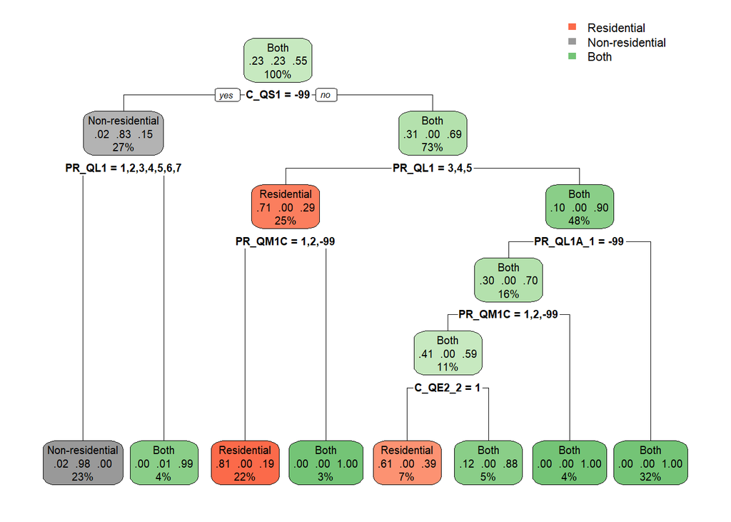

```r
# install.packages("rpart.plot")

library(rpart)
library(rpart.plot)
fit <- rpart(SERVICES~., data = subset_train, method = 'class')
rpart.plot(fit, extra = "auto")
```

Let us test the model by making a prediction

```r
predict_services <-predict(fit, subset_test, type = 'class')

table_Dss <- table(subset_test$SERVICES, predict_services)

table_Dss
```

```
##                  predict_services
##                   Residential Non-residential Both
##   Residential            1462              38   38
##   Non-residential           0            1513    4
##   Both                    488               5 3175
```